# **CMU 16825 Learning for 3D Vision – Assignment 3 Submission**

### MLP for Neural Surface Representation

The Multi-Layer Perceptron (MLP) is used to learn an implicit Signed Distance Function (SDF) for surface reconstruction. It takes 3D point coordinates (x, y, z) as input and predicts the signed distance to the nearest surface. The MLP consists of multiple fully connected layers (Linear layers) with ReLU activations and an optional positional encoding to enhance high-frequency details. A skip connection is introduced at layer 3 to help the network learn long-range dependencies. The final layer outputs a single signed distance value without an activation function, allowing it to be both positive and negative.

### Eikonal Loss

The Eikonal loss enforces the SDF property ||∇Φ(x)|| = 1, ensuring a smooth and well-behaved distance field. It is computed as the mean squared deviation of the gradient L2-norm from 1. This regularization prevents gradient exploding or vanishing issues and helps in reconstructing a more accurate surface. The loss is particularly important for learning well-defined level sets of the SDF, ensuring that the implicit surface remains sharp and physically meaningful.

## Task 7: VolSDF (15 points)

The following shows the hyperparameters tuning on alpha and beta:

Keeps beta = 0.05, alternating alpha values:

alpha=0.1

alpha=1.0

alpha=5.0

alpha=15

alpha=50

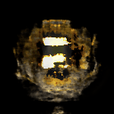

[figure not shown]

[figure not shown]

[figure not shown]

[figure not shown]

alpha=0.1

alpha=1.0

alpha=5.0

alpha=15

alpha=50

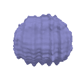

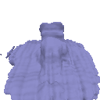

[figure not shown]

[figure not shown]

[figure not shown]

We can see that the best result is alpha = 15, under beta = 0.05.

On the other hyperparameter, we keep alpha = 15, alternating beta values:

beta=0.025

beta=0.05

beta=0.1

beta=0.2

[figure not shown]

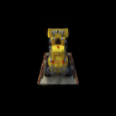

[figure not shown]

[figure not shown]

beta=0.025

beta=0.05

beta=0.1

beta=0.2

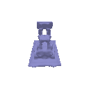

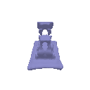

[figure not shown]

[figure not shown]

We can see that the best result is beta = 0.05, under alpha = 15.

The best result is alpha = 15, beta = 0.05:

My best color result

My best geometry result

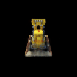

[figure not shown]

### Observations from the Results:

1. Alpha (α) - A scaling factor that controls the overall magnitude of the density function:

Higher α → Sharper surface transition between empty space and the object.

Lower α → More gradual transition, leading to a softer surface.

2. Beta (β) - Determines how smoothly the density transitions around the zero level set of the SDF:

Higher β → Leads to excessive blurring in the color image.

Lower β → Produces a more distinct rendering.

### Answer of the Questions:

1. How does high beta bias your learned SDF? What about low beta?

High beta leads to a blurred transition from occupied to free space, meaning the density function is spread out over a larger region. This can make the rendered color looks blurry because the density does not sharply define a surface.

Low beta makes the transition sharper, forcing the SDF to define a sharply bounded surface. This is better for sharp and accurate geometry but may cause instability if set too low.

2. Would an SDF be easier to train with volume rendering and low beta or high beta? Why?

An SDF is easier to train with a moderate or higher beta, rather than a very low beta because higher beta results in smoother gradients, making optimization more stable, but if the beta is too high, it would make that training harder because the density is too spread out, making it difficult to accurately localize the surface.

If beta is too low, the SDF behaves almost like a binary indicator function, making the optimization harder. Specifically, low beta would make gradient-based optimization struggle with extremely sharp transition, as tiny updates may cause significant changes in the output.

A moderate beta (e.g., 0.05 in my experiments) ensures that the SDF still provides a well-defined surface while keeping training stable.

3. Would you be more likely to learn an accurate surface with high beta or low beta? Why?

It would be more likely to learn an accurate surface with low beta (but not too low), because low beta leads to a more accurate surface.

On the other hand, high beta results in soft density transitions, making the surface poorly defined and blurry, and thereby harder to be used with to learn an accurate surface.

From my expereiments above, moderate beta (e.g., 0.05) provides a good balance between a well-defined surface and stable optimization.

## Task 8.1: Render a Large Scene with Sphere Tracing (10 points)

The following shows the result of rendering a large scene with 27 spheres. I defined a new class 'SceneSDF' in implicit.py to construct a 3×3×3 grid (each contains a Sphere, 'SceneSphereSDF' class in implicit.py, totally 27 Spheres) and compute the scene center as the mean of all sphere centers. The forward function evaluates the minimum SDF value across all spheres to define the scene’s implicit surface.

Large Scene w/ 27 Spheres

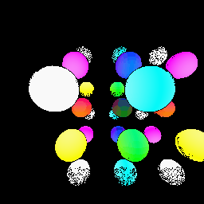

## Task 8.2: Fewer Training Views (10 points)

The following shows the results of restraining training views to 20, 10, 7 and 5 images on both NeRF and VolSDF training.

views=20

views=10

views=7

views=5

**NeRF**

[figure not shown]

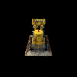

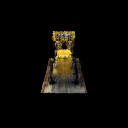

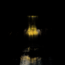

**VolSDF**

[figure not shown]

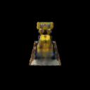

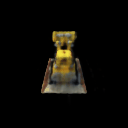

[figure not shown]

**VolSDF Geometry**

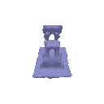

[figure not shown]

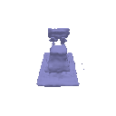

[figure not shown]

## Task 8.3: Alternate SDF to Density Conversions (10 points)

$$\phi_s(x) = s e^{-sx} / (1 + e^{-sx})^2$$

I implement the function as 'sdf_to_density_neus(sdf, s)' in implicit.py.

VolSDF

VolSDF Geometry

[figure not shown]

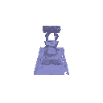